# Clustering Example

## Another way to write it down

Suppose we have a score \( S_i \), that score is related to a linear model. We add an “indicator” or “dummy variable”, stands in for logical variable.

eq: slide 7/20

The notation \( (Ra_i=" PG ") \) is a logical value that is one if the movie rating is “PG” and zero otherwise.

### Average values

- \( b_0= \) average of the G movies
- \( b_0+b_1= \) average of the PG movies
- \( b_0+b_2= \) average of the PG-13 movies
- \( b_0+b_3= \) average of the R movies

### How you do this in R

Coerce to factor, we don't want to treat them to factors, so that R treats them not as continuous variables but factors.

```r
lm1 <- lm(movies$score ~ as.factor(movies$rating))
summary(lm1)
```

```
##
## Call:
## lm(formula = movies$score ~ as.factor(movies$rating))
##
## Residuals:
##    Min     1Q Median     3Q    Max
## -26.43  -9.98  -0.98   9.34  38.97
##
## Coefficients:
##                               Estimate Std. Error t value Pr(>|t|)
## (Intercept)                      67.65       7.19    9.40   <2e-16 ***
## as.factor(movies$rating)PG      -12.59       7.85   -1.60     0.11
## as.factor(movies$rating)PG-13   -11.81       7.41   -1.59     0.11
## as.factor(movies$rating)R       -12.02       7.48   -1.61     0.11
## ---
## Signif. codes:  0 '***' 0.001 '**' 0.01 '*' 0.05 '.' 0.1 ' ' 1
##
## Residual standard error: 14.4 on 136 degrees of freedom
## Multiple R-squared: 0.0199,  Adjusted R-squared: -0.00177
## F-statistic: 0.918 on 3 and 136 DF,  p-value: 0.434
```

If you're a PG movie, you have 67.65-12.59 rating. None of the p-values are significant and t values are small, probably because there's so few points among G points, hard to tell if we observe difference.

### Plot fitted values

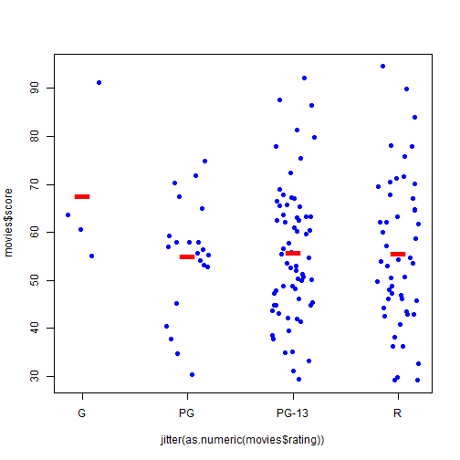

```r
plot(movies$score ~ jitter(as.numeric(movies$rating)), col = "blue", xaxt = "n",
    pch = 19)
axis(side = 1, at = unique(as.numeric(movies$rating)), labels = unique(movies$rating))
points(1:4, lm1$coeff[1] + c(0, lm1$coeff[2:4]), col = "red", pch = "-", cex = 5)
```

Means within each group

#### Question 1

Average values:

- \( b_0= \) average of the G movies
- \( b_0+b_1= \) average of the PG movies
- \( b_0+b_2= \) average of the PG-13 movies
- \( b_0+b_3= \) average of the R movies

**What is the average difference in rating between G and R movies?* \( b_0+b_3-b_0=b_3 \)

#### Question 1 in R

```r
lm1 <- lm(movies$score ~ as.factor(movies$rating))
summary(lm1)
```

```
##
## Call:
## lm(formula = movies$score ~ as.factor(movies$rating))
##
## Residuals:
##    Min     1Q Median     3Q    Max
## -26.43  -9.98  -0.98   9.34  38.97
##
## Coefficients:
##                               Estimate Std. Error t value Pr(>|t|)
## (Intercept)                      67.65       7.19    9.40   <2e-16 ***
## as.factor(movies$rating)PG      -12.59       7.85   -1.60     0.11
## as.factor(movies$rating)PG-13   -11.81       7.41   -1.59     0.11
## as.factor(movies$rating)R       -12.02       7.48   -1.61     0.11
## ---
## Signif. codes:  0 '***' 0.001 '**' 0.01 '*' 0.05 '.' 0.1 ' ' 1
##
## Residual standard error: 14.4 on 136 degrees of freedom
## Multiple R-squared: 0.0199,  Adjusted R-squared: -0.00177
## F-statistic: 0.918 on 3 and 136 DF,  p-value: 0.434
```

#### Question 2

Average values:

- \( b_0= \) average of the G movies
- \( b_0+b_1= \) average of the PG movies
- \( b_0+b_2= \) average of the PG-13 movies
- \( b_0+b_3= \) average of the R movies

What is the average difference in rating between PG-13 and R movies? \( b_0+b_2-(b_0+b_3)=b_2-b_3 \)

We don't get the estimate of \( b_2-b_3 \) from our standard linear model using the defaults, but

### We could rewrite our model

eq: slide 14/20

We reorder model to create a different set of indicator variables.

Average values:

- \( b_0= \) average of the R movies
- \( b_0+b_1= \) average of the G movies
- \( b_0+b_2= \) average of the PG movies
- \( b_0+b_3= \) average of the PG-13 movies

What is the average difference in rating between PG-13 and R movies? \( b_0 + b_3 - b_0=b_3 \)

#### Question 2 in R

We need to tell R what is the reference category, the one used in the intercept term.

```r
lm2 <- lm(movies$score ~ relevel(movies$rating, ref = "R"))
summary(lm2)
```

```
##
## Call:
## lm(formula = movies$score ~ relevel(movies$rating, ref = "R"))
##
## Residuals:
##    Min     1Q Median     3Q    Max
## -26.43  -9.98  -0.98   9.34  38.97
##
## Coefficients:
##                                        Estimate Std. Error t value
## (Intercept)                              55.630      2.035   27.34
## relevel(movies$rating, ref = "R")G       12.020      7.476    1.61
## relevel(movies$rating, ref = "R")PG      -0.573      3.741   -0.15
## relevel(movies$rating, ref = "R")PG-13    0.205      2.706    0.08
##                                        Pr(>|t|)
## (Intercept)                              <2e-16 ***
## relevel(movies$rating, ref = "R")G         0.11
## relevel(movies$rating, ref = "R")PG        0.88
## relevel(movies$rating, ref = "R")PG-13     0.94
## ---
## Signif. codes:  0 '***' 0.001 '**' 0.01 '*' 0.05 '.' 0.1 ' ' 1
##
## Residual standard error: 14.4 on 136 degrees of freedom
## Multiple R-squared: 0.0199,  Adjusted R-squared: -0.00177
## F-statistic: 0.918 on 3 and 136 DF,  p-value: 0.434
```

Now the difference is 0.205.

You can use `confint` to calculate the difference in average score between PG-13 and R mvoies and again, it covers 0, so it's unlikely that there's a major difference.

```r
lm2 <- lm(movies$score ~ relevel(movies$rating, ref = "R"))
confint(lm2)
```

```
##                                         2.5 % 97.5 %
## (Intercept)                            51.606 59.654
## relevel(movies$rating, ref = "R")G     -2.763 26.803
## relevel(movies$rating, ref = "R")PG    -7.971  6.825
## relevel(movies$rating, ref = "R")PG-13 -5.146  5.557
```

#### Question 3

Average values:

- \( b_0= \) average of the G movies
- \( b_0+b_1= \) average of the PG movies
- \( b_0+b_2= \) average of the PG-13 movies
- \( b_0+b_3= \) average of the R movies

Is there any difference in score between any of the movie ratings?

We do this using ANOVA - Analysis of variance. We get an analysis of variance table.

```r
lm1 <- lm(movies$score ~ as.factor(movies$rating))
anova(lm1)
```

```
## Analysis of Variance Table
##
## Response: movies$score
##                           Df Sum Sq Mean Sq F value Pr(>F)
## as.factor(movies$rating)   3    570     190    0.92   0.43
## Residuals                136  28149     207
```

The degrees of freedom tells us how many parameters we had to estimate for table and residuals is the number of movies - deg freedom, mean square is sum of squares divided by deg reedom, F value is the ratio of Mean sq for rating factor and residuals.

The F value can be interpreted on the scale of averages of movie scores. The P value has the usual property that if there is no difference across any of the ratings levels, it will have uniform distribution and it will be slightly less than the uniform distribution if there's something going on. The p-value in this case doesn't suggest much difference between categories.

#### Sum of squares (G movies)

The mean square for the factor variable in this case will be almost equal to sum of the distances from the fitted values in the G movies (blue) to the overall average (red).

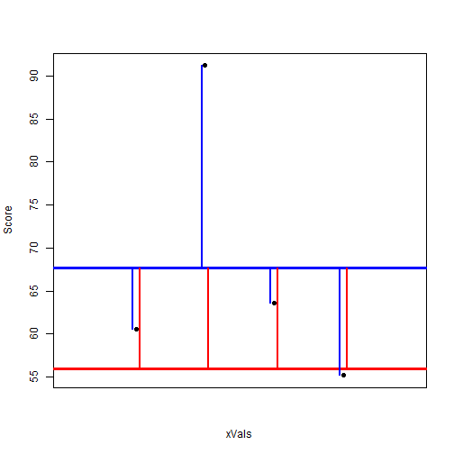

```r
gMovies <- movies[movies$rating == "G", ]
xVals <- seq(0.2, 0.8, length = 4)
plot(xVals, gMovies$score, ylab = "Score", xaxt = "n", xlim = c(0, 1), pch = 19)
abline(h = mean(gMovies$score), col = "blue", lwd = 3)
abline(h = mean(movies$score), col = "red", lwd = 3)
segments(xVals + 0.01, rep(mean(gMovies$score), length(xVals)), xVals + 0.01,
    rep(mean(movies$score), length(xVals)), col = "red", lwd = 2)
segments(xVals - 0.01, gMovies$score, xVals - 0.01, rep(mean(gMovies$score),
    length(xVals)), col = "blue", lwd = 2)
```

```r
lm1 <- lm(movies$score ~ as.factor(movies$rating))
anova(lm1)
```

```
## Analysis of Variance Table
##
## Response: movies$score
##                           Df Sum Sq Mean Sq F value Pr(>F)
## as.factor(movies$rating)   3    570     190    0.92   0.43
## Residuals                136  28149     207
```

The denominator term, which is the sum of squares for the residuals is the sum of distances from the actual data points to the fitted values. If the fitted value is really close to the data points, the residual terms will be very small (denominator). The numerator is how far the fitted value is from the overall average - how far we had to move from this group to get a really good fit. So if red numbers are really big and blue are really small, we've done good job of moving the line to fit the data points.

#### Turkey's (honestly significant difference test)

```r
lm1 <- aov(movies$score ~ as.factor(movies$rating))
TukeyHSD(lm1)
```

```
##   Tukey multiple comparisons of means
##     95% family-wise confidence level
##
## Fit: aov(formula = movies$score ~ as.factor(movies$rating))
##
## $`as.factor(movies$rating)`
##              diff     lwr    upr  p adj
## PG-G     -12.5929 -33.008  7.822 0.3795
## PG-13-G  -11.8146 -31.092  7.463 0.3854
## R-G      -12.0200 -31.464  7.424 0.3776
## PG-13-PG   0.7782  -8.615 10.171 0.9964
## R-PG       0.5729  -9.158 10.304 0.9987
## R-PG-13   -0.2054  -7.245  6.834 0.9998
```

`aov` is another way to do anova. This is going to calculate differences between 2-tuples of factor variables. lwr, upr are lower and upper confidence bounds for the differences. This is family-wise confidence interval, it means that we've adjusted the p-values for the fact that we made a whole bunch of different comparisons. So if we call p-values significant < 0.05, we won't get a lot more false positive results because we've accounted for the fact we've done all possible comparisons.

# Multiple Regression

Key Ideas

- Regression with multiple covariates
- Still using least squares/central limit theorem
- Interpretation depends on all variables

Data from Millenium Development Goal

## WHO Childhood hunger data

Using just both males and females

```r
if (!file.exists("./data/hunger.txt")) {
    download.file("http://apps.who.int/gho/athena/data/GHO/WHOSIS_000008.csv?profile=text&filter=COUNTRY:*;SEX:*",
        "./data/hunger.csv")
}
hunger <- read.csv("./data/hunger.csv")
hunger <- hunger[hunger$Sex != "Both sexes", ]
head(hunger)
```

```
##                                 Indicator Data.Source     Country    Sex
## 2  Children aged <5 years underweight (%) NLIS_312819 Afghanistan Female
## 3  Children aged <5 years underweight (%) NLIS_312819 Afghanistan   Male
## 6  Children aged <5 years underweight (%) NLIS_312361     Albania   Male
## 7  Children aged <5 years underweight (%) NLIS_312361     Albania Female
## 9  Children aged <5 years underweight (%) NLIS_312879     Albania   Male
## 10 Children aged <5 years underweight (%) NLIS_312879     Albania Female
##    Year            WHO.region Display.Value Numeric Low High Comments
## 2  2004 Eastern Mediterranean          33.0    33.0  NA   NA       NA
## 3  2004 Eastern Mediterranean          32.7    32.7  NA   NA       NA
## 6  2000                Europe          19.6    19.6  NA   NA       NA
## 7  2000                Europe          14.2    14.2  NA   NA       NA
## 9  2005                Europe           7.3     7.3  NA   NA       NA
## 10 2005                Europe           5.8     5.8  NA   NA       NA
```

### Plot percent hunbry versus time

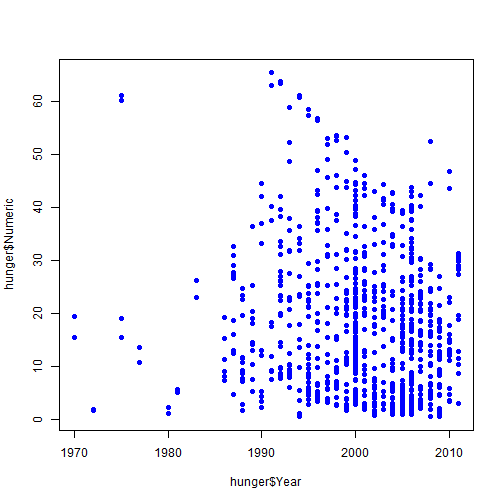

```r
lm1 <- lm(hunger$Numeric ~ hunger$Year)
plot(hunger$Year, hunger$Numeric, pch = 19, col = "blue")
```

### Remember the linear model

\[ Hu_i=b_0+b_1Y_i+e_i \]

- \( b_0= \) percent hungry at Year 0
- \( b_1= \) decrease in percent hungry per year
- \( e_i= \) everything we didn't measure

### Add the linear model

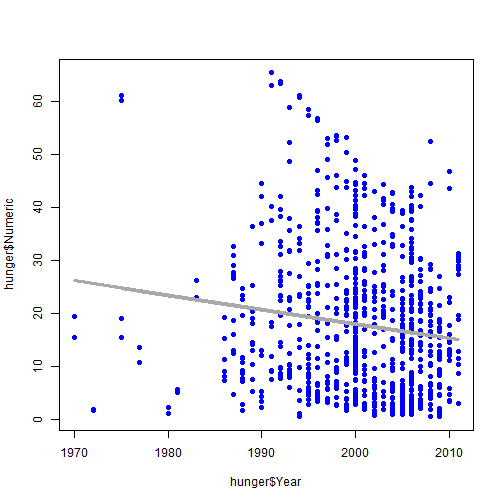

```r
lm1 <- lm(hunger$Numeric ~ hunger$Year)
plot(hunger$Year, hunger$Numeric, pch = 19, col = "blue")
lines(hunger$Year, lm1$fitted, lwd = 3, col = "darkgrey")
```

### Color by male/female

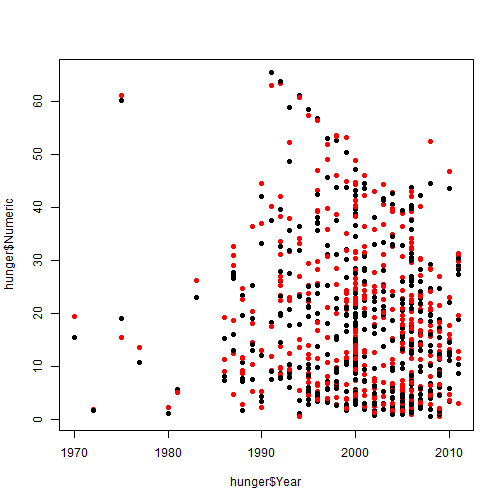

```r
plot(hunger$Year, hunger$Numeric, pch = 19)
points(hunger$Year, hunger$Numeric, pch = 19, col = ((hunger$Sex == "Male") *
    1 + 1))
```

## Now two lines

Separate lines for males and females

\[ HuF_i=bf_0+bf_1YF_i+ef_i \]

- \( bf_0= \) percent of girls hungry at Year 0
- \( bf_1= \) decrease in percent of girls hungry per year
- \( ef_i= \) everything we didn't measure

\[ HuM_i=bm_0+bm_1YM_i+em_i \]

- \( bm_0= \) percent of boys hungry at Year 0
- \( bm_1= \) decrease in percent of boys hungry per year
- \( em_1= \) everything we didn't measure

### Color by male/female

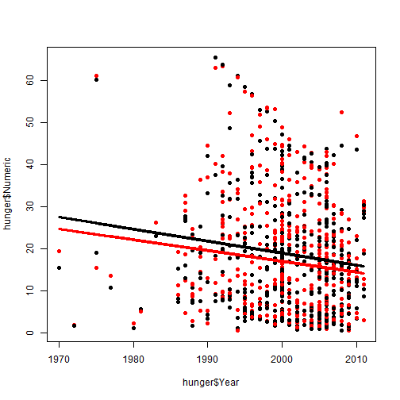

```r
lmM <- lm(hunger$Numeric[hunger$Sex == "Male"] ~ hunger$Year[hunger$Sex == "Male"])
lmF <- lm(hunger$Numeric[hunger$Sex == "Female"] ~ hunger$Year[hunger$Sex ==
    "Female"])
plot(hunger$Year, hunger$Numeric, pch = 19)
points(hunger$Year, hunger$Numeric, pch = 19, col = ((hunger$Sex == "Male") *
    1 + 1))
lines(hunger$Year[hunger$Sex == "Male"], lmM$fitted, col = "black", lwd = 3)
lines(hunger$Year[hunger$Sex == "Female"], lmF$fitted, col = "red", lwd = 3)
```

About the same slope, but girl children went slightly less hungry.

### Two lines, same slope

Slide 11/16

One slope for both lines, \( b_2Y_i \) - percent change of hungry for either males or females in a single year. This affects how we interpret the variables that we get out, fit the model and results.

#### Two lines, same sloper in R

Fitting the model from above, separate by Year and Sex in `lm`.

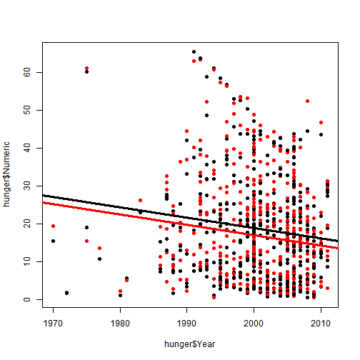

```r
lmBoth <- lm(hunger$Numeric ~ hunger$Year + hunger$Sex)
plot(hunger$Year, hunger$Numeric, pch = 19)
points(hunger$Year, hunger$Numeric, pch = 19, col = ((hunger$Sex == "Male") *
    1 + 1))
abline(c(lmBoth$coeff[1], lmBoth$coeff[2]), col = "red", lwd = 3)
abline(c(lmBoth$coeff[1] + lmBoth$coeff[3], lmBoth$coeff[2]), col = "black",
    lwd = 3)
```

Looks a lot like the plot from before.

### Two lines different slopes (interactions)

Slide 13/16

We can allow each line to have different slope.

#### In R

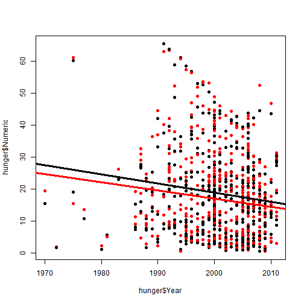

```r
lmBoth <- lm(hunger$Numeric ~ hunger$Year + hunger$Sex + hunger$Sex * hunger$Year)
plot(hunger$Year, hunger$Numeric, pch = 19)
points(hunger$Year, hunger$Numeric, pch = 19, col = ((hunger$Sex == "Male") *
    1 + 1))
abline(c(lmBoth$coeff[1], lmBoth$coeff[2]), col = "red", lwd = 3)
abline(c(lmBoth$coeff[1] + lmBoth$coeff[3], lmBoth$coeff[2] + lmBoth$coeff[4]),
    col = "black", lwd = 3)
```

```r
summary(lmBoth)
```

```
##
## Call:
## lm(formula = hunger$Numeric ~ hunger$Year + hunger$Sex + hunger$Sex *
##     hunger$Year)
##
## Residuals:
##    Min     1Q Median     3Q    Max
## -25.20 -11.61  -2.14   7.26  46.14
##
## Coefficients:
##                            Estimate Std. Error t value Pr(>|t|)
## (Intercept)                530.9361   191.7086    2.77   0.0057 **
## hunger$Year                 -0.2569     0.0958   -2.68   0.0075 **
## hunger$SexMale              59.5787   271.1169    0.22   0.8261
## hunger$Year:hunger$SexMale  -0.0288     0.1355   -0.21   0.8317
## ---
## Signif. codes:  0 '***' 0.001 '**' 0.01 '*' 0.05 '.' 0.1 ' ' 1
##
## Residual standard error: 13.5 on 856 degrees of freedom
## Multiple R-squared: 0.0233,  Adjusted R-squared: 0.0199
## F-statistic: 6.82 on 3 and 856 DF,  p-value: 0.000152
```

Summary includes both terms and interaction term. In result indicated by colon ':'.

Coefficient -.0.0288 is small, which is why the slopes aren't too different.

## Interactions for continuous variables

We can include quantitative temrs and interactions in multiple regression models. Say we have an income variable, In, and interaction between income and year.

\[ Hu_i=b_0+b_1In_i+b_2Y_i+b_3In_i\times Y_i+e^+_i \]

- \( b_0= \) percent hungry at year zero for children with whose parents have no income
- \( b_1= \) change in percent hungry for each dollar of income in year zero
- \( b_2= \) change in percent hungry in one year for children whose parents have no income
- \( b_3= \) increased change in percent hungry by year for each dollar of income - e.g. if income is $10000, then change in percent hungry in one year will be

\[ b_2+1e4\times b_3 \]

\( e_i^+ \) - everything we didn't measure

# Regression in real world

Things to pay attention to

- Confounders
- Complicated interactions - continuous vars
- Skewness
- Outliers
- Non-linear patterns
- Variance changes
- Units/scale issues
- Overloading regression
- Correlation and causation

## The ideal data for regression

Looks line an oval - multivariate, normal.

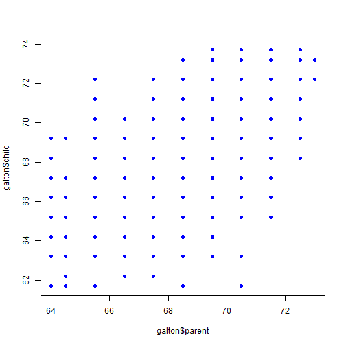

```r
library(UsingR)
data(galton)
plot(galton$parent, galton$child, col = "blue", pch = 19)
```

## Confounders

In real life data can contain **confounders**: A variable that is correlated with both the outcome and the covariates.

- Confounders can change the regression line
- They can even change the sign of the line
- They can sometimes be detected by careful exploration

## WHO Childhood hunger data

```r
download.file("http://apps.who.int/gho/athena/data/GHO/WHOSIS_000008.csv?profile=text&filt\ner=COUNTRY:*;SEX:*",
    "./data/hunger.csv")
```

```
## Error: cannot open URL
## 'http://apps.who.int/gho/athena/data/GHO/WHOSIS_000008.csv?profile=text&filt
## er=COUNTRY:*;SEX:*'
```

```r
hunger <- read.csv("./data/hunger.csv")
```

```
## Error: no lines available in input
```

```r
hunger <- hunger[hunger$Sex != "Both sexes", ]
head(hunger)
```

```
##                                 Indicator Data.Source     Country    Sex
## 2  Children aged <5 years underweight (%) NLIS_312819 Afghanistan Female
## 3  Children aged <5 years underweight (%) NLIS_312819 Afghanistan   Male
## 6  Children aged <5 years underweight (%) NLIS_312361     Albania   Male
## 7  Children aged <5 years underweight (%) NLIS_312361     Albania Female
## 9  Children aged <5 years underweight (%) NLIS_312879     Albania   Male
## 10 Children aged <5 years underweight (%) NLIS_312879     Albania Female
##    Year            WHO.region Display.Value Numeric Low High Comments
## 2  2004 Eastern Mediterranean          33.0    33.0  NA   NA       NA
## 3  2004 Eastern Mediterranean          32.7    32.7  NA   NA       NA
## 6  2000                Europe          19.6    19.6  NA   NA       NA
## 7  2000                Europe          14.2    14.2  NA   NA       NA
## 9  2005                Europe           7.3     7.3  NA   NA       NA
## 10 2005                Europe           5.8     5.8  NA   NA       NA
```

## Hunger over time by region

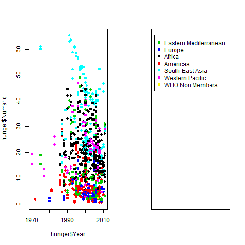

```r
par(mfrow = c(1, 2))
plot(hunger$Year, hunger$Numeric, col = as.numeric(hunger$WHO.region), pch = 19)
plot(1:10, type = "n", xaxt = "n", yaxt = "n", xlab = "", ylab = "")
legend(1, 10, col = unique(as.numeric(hunger$WHO.region)), legend = unique(hunger$WHO.region),
    pch = 19)
```

## Region correlated with year

```r
anova(lm(hunger$Year ~ hunger$WHO.region))
```

```
## Analysis of Variance Table
##
## Response: hunger$Year
##                    Df Sum Sq Mean Sq F value Pr(>F)
## hunger$WHO.region   6    623   103.8    2.25  0.037 *
## Residuals         853  39316    46.1
## ---
## Signif. codes:  0 '***' 0.001 '**' 0.01 '*' 0.05 '.' 0.1 ' ' 1
```

Moderate F and significant p

## Region correlated with hunger

```r
anova(lm(hunger$Numeric ~ hunger$WHO.region))
```

```
## Analysis of Variance Table
##
## Response: hunger$Numeric
##                    Df Sum Sq Mean Sq F value Pr(>F)
## hunger$WHO.region   6  76522   12754     129 <2e-16 ***
## Residuals         853  84211      99
## ---
## Signif. codes:  0 '***' 0.001 '**' 0.01 '*' 0.05 '.' 0.1 ' ' 1
```

Large F and small p, strong correlation.

## Including region - a complicated interaction

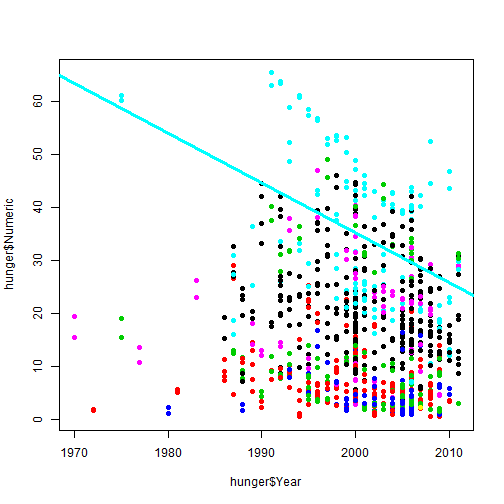

```r
plot(hunger$Year, hunger$Numeric, pch = 19, col = as.numeric(hunger$WHO.region))
lmRegion <- lm(hunger$Numeric ~ hunger$Year + hunger$WHO.region + hunger$Year *
    hunger$WHO.region)
abline(c(lmRegion$coeff[1] + lmRegion$coeff[6], lmRegion$coeff[2] + lmRegion$coeff[12]),
    col = 5, lwd = 3)
```

Correlated percent that are hungry to year, region, interaction bw year and region. If you include year and region, for every correlation, you'll get a different regression line. It starts to get complicated to identify which coefficients of lmregion to include in abline.

## Income data

UCI data, census

```r
download.file("http://archive.ics.uci.edu/ml/machine-learning-databases/adult/adult.data",
    "./data/income.csv")
incomeData <- read.csv("./data/income.csv", header = FALSE)
income <- incomeData[, 3]
age <- incomeData[, 1]
```

## Logs to address right-skew

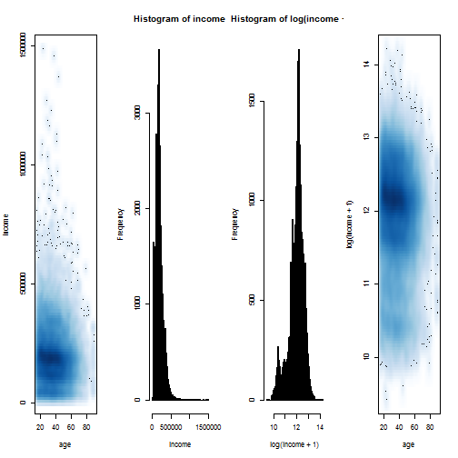

```r
par(mfrow = c(1, 4))
smoothScatter(age, income)
hist(income, col = "blue", breaks = 100)
hist(log(income + 1), col = "blue", breaks = 100)
smoothScatter(age, log(income + 1))
```

## Outliers

“outliers” … are data points that do not appear to follow the pattern of the other data points.

## Example - extreme points

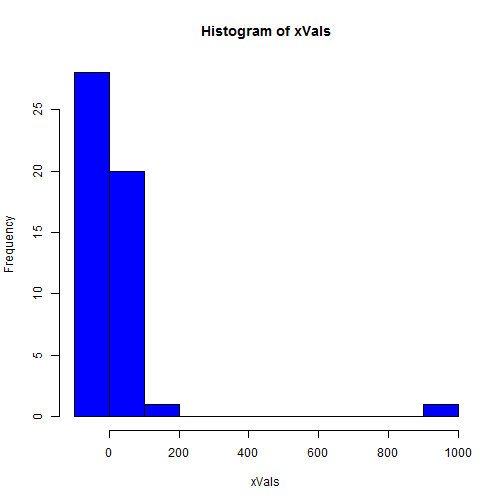

```r
set.seed(1235)
xVals <- rcauchy(50)
hist(xVals, col = "blue")
```

## Example - outliers may be real

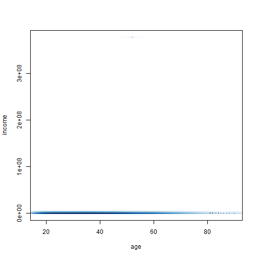

```r
# Add Tim Cook, CEO of Apple 2011 income
age <- c(age, 52)
income <- c(income, 3.78e+08)
smoothScatter(age, income)
```

It's not clear that you need to remove that point, because it is a real salary.

## Outliers - what you can do

- If you know they aren't real/of interest, remove them (but changes question!)
- Alternatively
  - Sensitivity analysis - is it a big difference if you leave it in/take it out?
  - Logs - if the data are right skewed (lots of outliers)
  - Robust methods - we've been doing averages, but there are more robust approaches (Robust, [rlm](http://stat.ethz.ch/R-manual/R-patched/library/MASS/html/rlm.html))

## A line isn't always the best summary

Slie 18/30

## Variance changes

Models assume there's a constant variability around the fit.

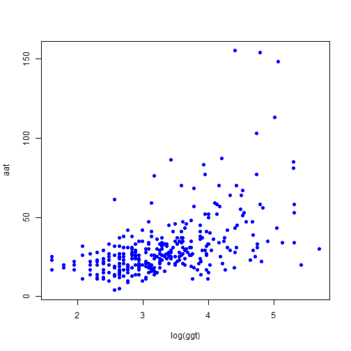

```r
bupaData <- read.csv("ftp://ftp.ics.uci.edu/pub/machine-learning-databases/liver-disorders/bupa.data")
ggt <- bupaData[, 5]
aat <- bupaData[, 3]
plot(log(ggt), aat, col = "blue", pch = 19)
```

## Plot the residuals

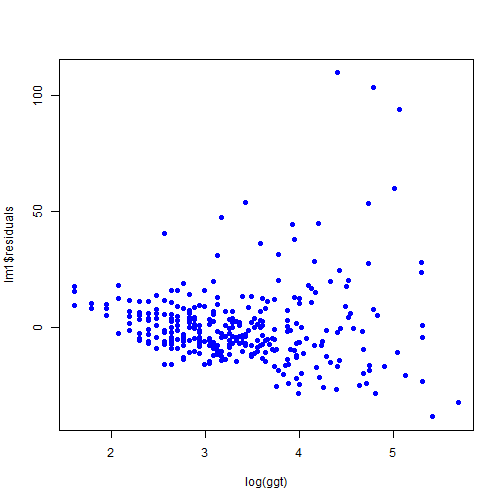

```r
lm1 <- lm(aat ~ log(ggt))
plot(log(ggt), lm1$residuals, col = "blue", pch = 19)
```

## Changing variance - what you can do

- Problem called heteroskedasticity
- examples:
  - Box-Cox Transform
  - Variance stabilization transform
  - Weighted least squares
  - Huber-white standard errors

## Variation in units

Slide 23/30

## Relative units

Slide 24/30

What you can do is divide the deaths by some denominator, in this case # of deaths/1000 children

## When there is variation in units

- Standardize, but keep track
  - Affects model fits
  - Affects interpretation
  - Affects inference

## Overloading regression

Fewer terms may be better.